# 第 4 章 数据预处理

本章介绍的方法由金融应用驱动。若希望了解非金融数据处理的入门内容，我们推荐两份参考：Boehmke and Greenwell (2019) 的通用机器学习教材第 3 章，以及 Kuhn and Johnson (2019) 关于这一专门主题的专著。

## 4.1 了解你的数据

和任何定量研究一样，第一步显然是确保数据可信，也就是说，至少应来自可靠的数据供应商。金融数据供应的版图非常广阔：有些供应商历史悠久（例如 Bloomberg、Thomson-Reuters、Datastream、CRSP、Morningstar），有些较新（例如 Capital IQ、Ravenpack），还有一些专注于另类数据细分领域（完整清单见 https://alternativedata.org/data-providers/）。遗憾的是，据我们所知，目前还没有公开研究从数据可靠性角度评估大范围的数据供应商。

第二步是查看**汇总统计量**：取值范围（最小值和最大值）、均值和中位数。直方图或时间序列图当然包含更多信息，但在高维情形下无法被充分分析。不过，对于某只股票和/或某个特征，它们有时有助于追踪局部模式或错误。除一阶矩外，二阶量（方差与协方差/相关性）也很重要，因为它们有助于发现共线性。当两个特征高度相关时，某些模型（例如简单回归，见第 15.1 节）可能会出现问题。

通常，预测变量数量很大，以至于逐一查看这些简单指标并不实际。仍建议做最低限度的核验。为了进一步简化分析：

- 聚焦于一部分预测变量，例如与最常见因子相关的变量（市值、市净率或账面市值比、动量（过去收益率）、盈利能力、资产增长、波动率）；
- 在汇总统计量中追踪异常值（当最大值/中位数或中位数/最小值比率看起来可疑时）。

图 4.1 以蜂群图展示特征与未来一个月收益率之间相关系数的分布。这些相关系数逐日期、基于当日全部股票的横截面计算。它们大多接近零，但某些日期似乎出现了极端偏移。市值与收益率的相关系数中位数最低且为负，而波动率是唯一一个相关系数中位数为正的预测变量（这个特定例子似乎否定了低风险异象）。

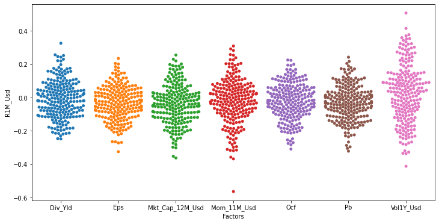

```python
import seaborn as sns
import matplotlib.pyplot as plt

cols=[]                                 # cleaning the column list from previous use
cols= features_short+['R1M_Usd','date'] # Keep few features, label & dates
data_corr = data_ml[cols]               # Creating the working dataset
data_corr = data_corr.groupby('date').corr()[['R1M_Usd']].reset_index() # Group for computing correlation
data_corr= data_corr.loc[data_corr[data_corr.level_1.str[-7:] != "R1M_Usd"].index] # removing correl=1 instances from label
data_corr.rename(columns={'level_1': "Factors"},inplace=True) # Renaming fro plotting later
plt.figure(figsize=(12,6))              # resizing the chart
sns.swarmplot(x="Factors", y="R1M_Usd", data=data_corr); # Plot from seaborn
```

图 4.1：各特征与未来 1 个月收益率（标签）相关性的蜂群图。

更重要的是，当我们希望使用监督学习（本书大多数时候都会如此）时，可以通过平滑后的**条件期望**（即条件均值）进一步刻画某些特征与因变量之间的关系，因为它反映了特征如何影响标签。使用条件期望有深厚的理论基础。假设只有一个特征  
$X$，并且我们寻求模型 $Y=f(X)+\text{error}$，其中变量均为实值。使平均平方误差 $\mathbb{E}[(Y-f(X))^2]$ 最小的函数 $f$ 被称为回归函数（见 Hastie, Tibshirani, and Friedman (2009) 第 2.4 节）：

\begin{equation} \tag{4.1} f(x)=\mathbb{E}[Y|X=x]. \end{equation}

图 4.2 给出了该函数的两个例子，其中因变量（$Y$）是未来一个月收益率。第一个对应过去一年平均市值，第二个对应过去一年的波动率。这两个预测变量都已均匀化（见下文第 4.4.2 节），因此在任一给定时期内，它们在资产横截面上的取值均匀分布。因此，特征范围为 $[0,1]$，并显示在图的 $x$ 轴上。曲线周围的彩色带表示均值计算的 95% 置信区间。本质上，当 (i) 可用数据点很多且 (ii) 这些点分散程度不高时，置信区间会较窄。

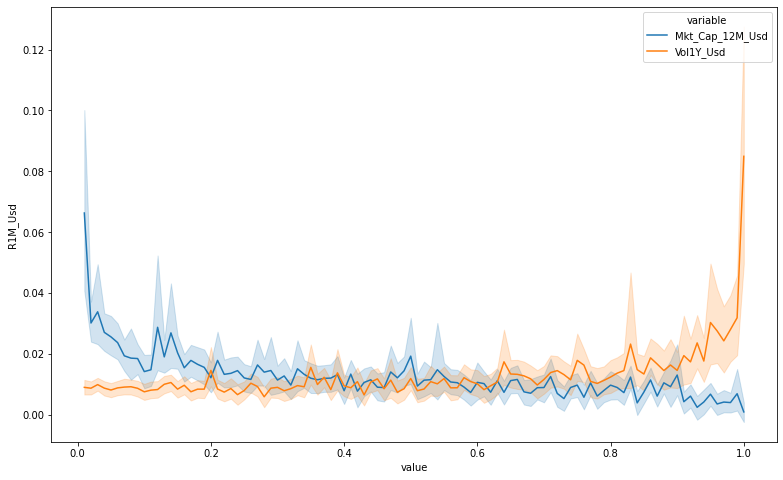

```python
from matplotlib import pyplot as plt
import seaborn as sns

unpivoted_data_ml = pd.melt(data_ml[['R1M_Usd','Mkt_Cap_12M_Usd','Vol1Y_Usd']], id_vars='R1M_Usd') # selecting and putting in vector
plt.figure(figsize=(13,8))
sns.lineplot(data = unpivoted_data_ml, y='R1M_Usd', x='value', hue='variable'); # Plot from seaborn
```

图 4.2：条件期望：平均收益率作为特征的平滑函数。

这两个变量对未来收益率的影响都接近单调。平均而言，收益率随市值上升而下降（从而支持所谓规模效应）。波动率的反向模式没有那么明显：在波动率得分的前半段，曲线相当平坦，随后逐步上升，尤其是在波动率取值的最高五分位附近（从而与低波动异象相矛盾）。

特征的一个重要经验性质是**自相关**（或其不存在）。某个预测变量具有较高自相关时，如果部分数据点缺失，使用简单插补技术就更有道理。但在进入预测任务时，自相关同样重要，我们将在第 4.6 节简要讨论这一问题。在图 4.3 中，我们构造自相关的直方图，自相关按股票逐只、按特征逐个计算。

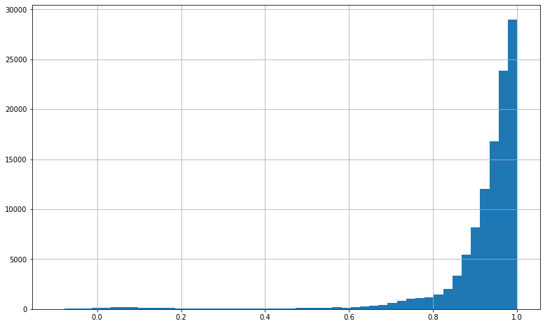

```python
cols=[]                                 # cleaning the column list from previous use
cols = ['stock_id'] + list(data_ml.iloc[:,3:95].columns) # Keep all features and stockid
# below the nested line of code for sorting according the pair stockid/variable and then compute the acf
data_hist_acf=pd.melt(data_ml[cols], id_vars='stock_id').groupby(['stock_id','variable']).apply(lambda x: x['value'].autocorr(lag=1))
plt.figure(figsize=(13,8))
data_hist_acf.hist(bins=50,range=[-0.1,1]); # Plot from pandas
```

图 4.3：样本特征自相关的直方图。

## 4.2 缺失数据

与任何经验学科类似，投资组合管理必然会面对缺失数据问题。该主题已广为人知，若干书籍详细讨论了解决方案（例如 Allison (2001)、Enders (2010)、Little and Rubin (2014) 以及 Van Buuren (2018)）。虽然研究者不断提出处理缺失点的新方法（仅举几例，Honaker and King (2010) 或 Che et al. (2018)），但我们认为，只要执行一些基本的谨慎防护，简单的启发式处理通常已经足够。

首先，处理缺失数据主要有两种方式：**删除**和**插补**。删除法不作额外假设，但代价很高，尤其是仅因一个特征值缺失就删除整条观测时。插补法通常更受青睐，但它依赖某些隐含且可能错误的假设。

插补方法大致可以分为以下几类：

- 一种基本做法是使用该股票过去已有特征值的中位数或均值。如果时间序列存在趋势，这种做法仍会扭曲趋势。此外，除非分别处理训练集与测试集，否则还可能引入前视偏差。
- 在用于回测的时间序列中，最简单的做法是沿用前一期数值：若 $x_t$ 缺失，就以 $x_{t-1}$ 替代。多数情况下这样做是合理的，因为当时能够获得的只有历史信息，因此不会向前看。不过，在某些情形下，这可能是很差的选择（见下文警示）。
- 也可以在资产**横截面**上计算中位数或均值。这样会把缺失特征值集中填到已观测分布的中心区域。当缺失值很多时，特征分布会在填充值处形成一个点质量，从而改变原始分布。其优点是不会引入前视偏差。
- 许多方法依赖对数据生成过程的建模假设，包括基于随机森林的非参数方法（Stekhoven and Bühlmann (2011) 与 Shah et al. (2014)，见第 6 章）、贝叶斯插补（Schafer (1999)）、最大似然方法（Enders (2001), Enders (2010)）、插值或外推，以及最近邻算法（Garcı́a-Laencina et al. (2009)）。本小节开头引用的四本书更系统地讨论了这类插补流程。高级方法通常需要更多计算资源。

几点警示：

- 必须避免插值。对于按季度发布的会计数值或比率，绝不能进行线性插值，因为这会引入前视偏差。若数值分别在 1 月和 4 月披露，要插补 2 月和 3 月，就必须提前知道 4 月的数值，而真实交易中不可能获得这项未来信息。沿用过去值通常更合适。
- 不过，有些特征不应沿用过去值。首先，收益率不能简单复制。默认情况下，把缺失收益率设为零通常更合适，因为零往往接近其均值或中位数。判断能否沿用过去值时，可以考察特征的时间持续性：若特征高度自相关，且时间序列像市值一样平滑，沿用过去值可能合理；否则应避免。
- 有些情况需要更多关注。考虑以下虚构的股息收益率样本：

| 日期 | 原始股息率 | 替代值 |
| --- | --- | --- |
| 2015-02 | NA | 前值（如果存在） |
| 2015-03 | 0.02 | 保持不变（无） |
| 2015-04 | NA | 0.02（前值） |
| 2015-05 | NA | 0.02（前值） |
| 2015-06 | NA | <=问题！ |

表 4.1：按时间顺序插补的挑战。

在这个例子中，股息率按季度发布，披露月份为 3 月、6 月、9 月等，但 6 月的数值缺失。问题在于，我们无法判断这究竟是数据故障，还是公司当月确实没有派息。因此，沿用过去值可能会得到错误结果。这里没有完美方案，但仍需作出选择。对于股息数据，可以考虑三种做法：

1. 保留前一个值。在 R 中，zoo 包的 na.locf() 函数对这项任务非常高效。
2. 根据先前观测值进行外推（这与**插**值非常不同）：例如，用过去数据估计趋势，并沿该趋势延伸。
3. 将值设为零。这很有吸引力，但由于管理层存在股息平滑实践，可能并非最优（相关主题细节见 Leary and Michaely (2011) 以及 Chen, Da, and Priestley (2012)）。对于持续性时间序列，前两种选择可能更好。

可以通过测试比较各方案的相对表现。同样重要的是**记录**这些设计决策，因为选择很多，很容易遗漏。在机器学习工作流中，数据准备**脚本**尤其关键：它们通常会被反复运行，而不是只执行一次。

## 4.3 异常值检测

异常值检测同样已有丰富文献，包括多篇综述（Hodge and Austin (2004), Chandola, Banerjee, and Kumar (2009) 以及 Gupta et al. (2014)）和若干部专著（Aggarwal (2013) 与 Rousseeuw and Leroy (2005)，其中后者主要讨论回归分析）。

同样，极为复杂的方法可能耗费大量精力，却只能带来有限改进。只要在流程中清楚记录，简单的启发式方法往往已经足够。这些方法通常依赖“硬”阈值：

- 对于某个给定特征（可能经过时间筛选），任何落在区间 $[\mu-m\sigma, \mu+m\sigma]$ 之外的点都可视为异常值。这里 $μ$ 是样本均值，$σ$ 是标准差。倍数 $m$ 通常属于集合 $\{3, 5, 10\}$，这当然是任意的。
- 类似地，如果最大值超过第二大值的 $m$ 倍，也可以将其归类为异常值（尾部另一侧同理）。
- 最后，对于给定的小阈值 $q$，任何位于 $[q,1-q]$ 分位数范围之外的值都可视为异常值。

后一种思路通常通过缩尾处理实现。缩尾是把所有低于 x(q) 的值设为 $x^{(q)}$，把所有高于 x(1−q) 的值设为 x(1−q) 。缩尾后的变量 ~x 为：

$\tilde{x}_i=\left\{\begin{array}{ll} x_i & \text{ if } x_i \in [x^{(q)},x^{(1-q)}] \quad \text{ (unchanged)}\\ x^{(q)} & \text{ if } x_i < x^{(q)} \\ x^{(1-q)} & \text{ if } x_i > x^{(1-q)} \end{array} \right. .$

$q$ 的范围通常为 $(0.5\%, 5\%)$，其中 1% 和 2% 最常使用。

缩尾处理**必须**按特征、按日期分别执行。不过，同时保留时间序列视角也很有必要。例如，800B 美元的市值乍看可能异常，但结合苹果公司的市值历史来看，未必如此。

本小节最后提醒，真实异常值（即并非由数据提取错误导致的极端点）是有价值的，因为它们很可能携带重要信息。

## 4.4 特征工程

特征工程是投资组合构建中的关键步骤。计算机领域常说*“garbage in, garbage out”*，即输入质量决定输出质量。因此，不应让用于资产配置的机器学习模型在设计不当的变量上训练。关于这一主题，可参阅 Kuhn and Johnson (2019) 的专著；篇幅较短的学术参考文献是 Guyon and Elisseeff (2003)。

### 4.4.1 特征选择

第一步是特征选择。面对大量预测变量，剔除无用或冗余的变量是合理做法。常见的简单方法包括：

- 计算所有特征的相关矩阵，并检查相关系数绝对值是否超过某个阈值（0.7 是常用取值），以免冗余变量干扰模型训练；
- 执行线性回归，并移除不显著变量（例如 p 值高于 0.05 的变量）。
- 对特征集合进行聚类分析，并在每个聚类中只保留一个特征（见第 15 章）。

这些方法都有一定局限，也会忽略非线性关系。另一种做法是拟合决策树或随机森林，只保留重要性较高的特征。第 6 章将介绍树模型，第 13 章将讨论特征重要性。

### 4.4.2 缩放预测变量

金融数据的量纲和取值范围差异很大，因此需要预先处理：

- 收益率大多数时候绝对值小于一；
- 股票波动率通常位于 5% 到 80% 之间；
- 市值以某一货币的百万或十亿单位表示；
- 会计数值也是如此；
- 会计比率可能具有不一致的单位；
- 情绪等合成属性也有其自身特点。

通常认为，特征的单调变换只会对预测结果产生有限影响；但 Galili and Meilijson (2016) 表明事实并非总是如此（另见第 4.8.2 节）。因此，缩放方法的选择可能相当重要。

如果用 xi 表示原始输入，用 ~xi 表示变换后的数据，常见缩放做法包括：

- **标准化**：$\tilde{x}_i=(x_i-m_x)/\sigma_x$，其中 mx 和 σx 分别是 x 的均值和标准差；
- **min-max** 缩放到 [0,1]：$\tilde{x}_i=(x_i-\min(\mathbf{x}))/(\max(\mathbf{x})-\min(\mathbf{x}))$
- **min-max** 缩放到 [-1,1]：$\tilde{x}_i=2\frac{x_i-\min(\mathbf{x})}{\max(\mathbf{x})-\min(\mathbf{x})}-1$
- **均匀化**：$\tilde{x}_i=F_\mathbf{x}(x_i)$，其中 Fx 是 x 的经验分布函数。在这种情况下，向量 ~x 被定义为服从 [0,1] 上的均匀分布。

对于取值范围很大且含有极端值的变量，例如市值，可以先作对数变换，再进行缩放。显然，这种方法不能直接用于含有负值的特征。

例如，训练神经网络前，通常建议先把输入缩放到 [0,1] 区间。本书的数据集采用经过均匀化的变量：在每个时间点，每项特征在资产横截面上都均匀分布于单位区间。在因子投资中，特征缩放必须**按日期、按特征分别执行**。这能保证每个再平衡日的预测变量具有相近的分布形态，同时保留股票横截面上的相对信息。

均匀化有时会以不同方式表述：对于给定特征和时间，对特征值排序，再用秩除以非缺失点数量。例如 Freyberger, Neuhierl, and Weber (2020) 就采用这种做法。在 Kelly, Pruitt, and Su (2019) 中，作者也执行这一操作，但随后对所有特征减去 0.5，使其取值位于 [-0.5,0.5]。

不应跨日期缩放特征。以市值为例，若不考虑市场崩盘，其长期趋势通常向上。跨日期缩放会使样本初期的取值普遍较小、末期普遍较大，从而改变并稀释特征原有的横截面信息。

## 4.5 标签构造

### 4.5.1 简单标签

构建投资组合策略时，可以用多种方式定义标签。最终目标固然是得到投资组合权重，但权重本身很少是最合适的标签。10

因子投资中的常见标签如下：

- 原始资产收益率；
- 未来相对收益率（相对于某个基准：例如全市场指数或基于行业的组合）。一个简单选择是用收益率减去横截面均值或中位数；
- 正收益概率（或收益率高于指定阈值的概率）；
- 跑赢基准的概率（在给定时间窗口上计算）；
- 上述指标的二元版本：是（跑赢）与否（跑输）；
- 上述指标的风险调整版本：夏普比率、信息比率、MAR 或 CALMAR 比率（见第 12.3 节）。

构造二元标签时，一个自然做法是把收益率与零比较，区分盈利与非盈利。但这种标签高度依赖市场时期，并非理想选择：行情良好时，多数资产收益为正；市场崩盘时，则很少有资产取得正收益，因而类别会严重失衡。更好的办法是把收益率与时间 $t$ 的横截面中位数或均值比较，将样本分为两组。这样得到的是相对表现标签，两个类别也更均衡。

正如本章后面将讨论的，这些选择仍留下额外自由度。标签是否应像特征一样被缩放？计算表现指标的最佳时间期限是多长？

### 4.5.2 类别型标签

在典型的机器学习分析中，若 $y$ 是未来表现的代理变量，模型会尝试最小化预测值与已实现值之间的某种距离。为便于数学处理，通常使用平方误差和（$L^2$ 范数），因为其导数形式简单，便于应用梯度下降。

有时，比起关注收益率或夏普比率等原始表现代理变量，更有意思的是关注可由这些代理变量推导出的离散投资决策。一个简单例子（决策规则）如下：

\begin{equation} \tag{4.2} y_{t,i}=\left\{ \begin{array}{rll} -1 & \text{ if } & \hat{r}_{t,i} < r_- \\ 0 & \text{ if } & \hat{r}_{t,i} \in [r_-,r_+] \\ +1 & \text{ if } & \hat{r}_{t,i} > r_+ \\ \end{array} \right., \end{equation}

其中，$\hat{r}_{t,i}$ 是表现代理变量，例如收益率或夏普比率；$r_\pm$ 是决策阈值。当预测表现低于 $r−$ 时，决策为 -1（例如卖出）；高于 $r_+$ 时，决策为 +1（例如买入）；位于两者之间时，模型既不过度乐观也不过度悲观，决策为中性（例如持有）。表现代理变量也可以相对某个基准定义，使决策直接反映相对于基准的表现。通常建议选择合适的阈值 $r_\pm$，使三个类别所含样本数量大致相当。

在这种情况下，最终输出既可视为分类变量，也可视为数值变量，因为它属于一类重要的分类变量：有序分类（**ordinal**）变量。如果将 $y$ 作为数值，则可应用通常的回归工具。

当 $y$ 被视为无序（**nominal**）分类变量时，还需要额外处理，因为机器学习工具只能处理数值。最常用的转换称为“**one-hot encoding**”，即独热编码。类别向量被展开为一个稀疏矩阵，每一列对应一个类别，矩阵元素为零或一；样本所属类别对应的列取值为一。下表给出一个简单示例。

表 4.2：one-hot 编码的简洁示例。

[output not shown]

分类任务的输出维度更高。对每条观测，模型会给出其属于各个类别的概率。第 6 章和第 7 章将说明，这类输出可以用 softmax 函数方便地处理。

从资产配置角度看，处理分类预测并不一定容易。对于多空组合，正负一信号可以提供仓位方向。对于纯多头组合，有两种可能方案：(i) 使用二元类别（进入或不进入组合），或 (ii) 根据预测调整权重：预测为 -1 时权重为零，预测为 0 时权重为 0.5，预测为 +1 时满权重。当然，随后需要对权重归一化，以满足预算约束。

### 4.5.3 三重屏障法

本节最后介绍 De Prado (2018) 提到的一种高级标签构造技术。其思想是考虑交易策略的完整动态，而不是简单的表现代理变量。这一扩展的逻辑在于，资产管理人经常设置损益触发条件：收益达到一定水平时获利了结，亏损达到一定程度时退出止损。策略启动时，会设定三道屏障（见图 4.4）：

- 一道位于资产当前水平之上（品红色线），衡量合理的预期利润；
- 一道位于资产当前水平之下（青色线），作为止损信号以防止较大的负收益；
- 最后一道固定策略的期限，到期后策略终止（黑色线）。

如果策略触及第一道屏障，输出为 +1；触及第二道屏障，输出为 -1；若先触及最后一道时间屏障，输出可以设为零，也可以在 -1 与 +1 之间线性插值，以表示终值相对于上下两道水平屏障的位置。这一方法的**计算成本高得多**，因为每条观测都需要评估完整价格路径。不过，它也更贴近现实，因为交易策略往往配有止损等自动触发机制。

[figure not shown]

图 4.4：三重屏障法示意图。

### 4.5.4 过滤样本

机器学习的主要挑战之一是提取尽可能多的**信号**。这里的信号指能够在样本外成立的模式。直观上，人们可能认为收集的数据越多，可提取的信号也越多。但一般而言，这其实是错误的，因为更多数据也意味着更多噪声。令人意外的是，过滤训练样本可以提高表现。Fu et al. (2018)、Guida and Coqueret (2018a) 以及 Guida and Coqueret (2018b) 就成功实现了这一思路。

在 Coqueret and Guida (2020) 中，我们研究了为什么较小样本可能让某类特定机器学习算法——决策树（见第 6 章）取得更好的样本外准确率。我们关注一种特定过滤器：排除不极端的标签（例如收益率），保留最小的 20% 和最大的 20% 数值（分布主体被移除）。这样做会从两个方面改变树的结构：

- 当分裂点被改变时，它们总是更接近分裂变量分布的中心（即得到的簇更均衡，可能也更稳健）；
- 分裂变量的选择（有时）会被推向那些对标签具有单调影响的特征。

这两个性质都有益。第一，它降低了模型拟合到虚假小样本群组的风险；第二，它会提高那些整体上更能解释收益率的特征的重要性。不过，筛选不能过强。如果不再保留标签分布两端各 20% 的样本，而只保留两端各 10%，信号损失就会过大，模型表现反而恶化。

### 4.5.5 收益率期限

本小节讨论基于因子的机器学习模型中最少被争论的问题之一：期限。在整个机器学习驱动的配置流程中，会出现多个期限：**标签期限**、**估计窗口**（训练样本的时间深度）以及**持有期**。一个较早考察这些方面的参考文献，是 Jegadeesh and Titman (1993) 关于动量的奠基性学术论文。作者基于过去 $J=3, 6, 9, 12$ 个月收益率计算组合盈利能力，并测试四种持有期：$K=3,6,9,12$ 个月。他们报告：“*最成功的零成本（多空）策略，是根据过去 12 个月收益率选择股票，并持有组合 3 个月。*”虽然该研究完全没有使用机器学习，但其“期限很重要”的结论也可能适用于更复杂的方法。事实上，这一主题被广泛讨论，动量盈利能力中期限影响的持续争论就是例证（见 Novy-Marx (2012), Gong, Liu, and Liu (2015) 以及 Goyal and Wahal (2015)）。

使用机器学习算法时，也应考虑这一争论。估计窗口和持有期问题会在本书后面的第 12 章提及。自然地，在本章中，标签期限是关键组成部分。启发式地，如果为简单起见只考虑一个特征，则有四种可能组合：

1. 振荡标签与振荡特征；
2. 振荡标签与平滑特征（高度自相关）；
3. 平滑标签与振荡特征；
4. 平滑标签与平滑特征。

在所有这些选择中，最后一种可能更可取，因为在其他条件相同的情况下，它更稳健。11 所谓*其他条件相同*，是指每种情形下模型都能够提取某种相关模式。两个缓慢变化序列之间成立的模式更可能随时间持续。因此，由于特征通常高度自相关（参见图 4.3），将其与平滑标签结合可能是一个好主意。为了说明这一点有多关键，本书大多数例子会有意使用 1 个月收益率，并展示相应结果往往令人失望。这些收益率自相关很弱，而 6 个月或 12 个月收益率持续性更强，是更好的标签选择。

从理论上也可以理解这一现象。为简单起见，假设单一特征 $x$ 解释收益率 $r_{t+1}=f(x_t)+e_{t+1}$。如果 $xt$ 高度自相关，且 $e_{t+1}$ 中的噪声不太大，那么未来两期收益率 $(1+r_{t+1})(1+r_{t+2})-1$ 可能比 $r_{t+1}$ 包含更多信号，因为 $x_t$ 与收益率的关系会随时间传递并复合。由此，将记忆机制直接纳入模型也可能有益，例如 Matthew F Dixon (2020) 的做法。下一节讨论与自相关有关的若干实践问题。

## 4.6 处理持续性

虽然我们把特征工程和标签构造分成两个不同小节，但更明智的做法可能是将二者联合考虑。机器学习算法处理的数据集应具有一个重要性质：特征与标签之间的持续性一致。直观上，标签 $y_{t,n}$（未来表现）与特征 $x_{t,n}^{(k)}$ 之间的自相关模式不应相距太远。

一种典型的问题情形是：数据按月采样，这在资产管理行业并不少见；标签是月度收益率，特征则是风险或基本面属性。此时，标签的自相关很弱，特征却往往高度自相关。复杂预测工具会尝试从这些特征之间细微的相对差异中提取规律，很可能因此引入大量噪声。在线性预测模型中，已知这种设定会使估计产生偏误（见 Stambaugh (1999) 以及 Gonzalo and Pitarakis (2018) 的综述）。

面对这一问题时，除其他更技术性的选项外，有两种简单方案：要么向标签中引入自相关，要么从特征中去除自相关。同样，第一种方案不建议用于线性模型的统计推断。两者在计量上都相当容易：

- 要提高标签的自相关，可以在更长时间范围上计算表现。例如，当使用月度数据时，考虑年度或两年期收益率即可奏效。
- 要消除自相关，最直接的路径是使用差分/变化量：$\Delta x_{t,n}^{(k)}=x_{t,n}^{(k)}-x_{t-1,n}^{(k)}$。这一程序的一个优点是它在经济上有意义：相比原始水平，特征变化可能是更好的表现驱动因素。

在特征空间中混合持续性变量和振荡变量当然是可能的，只要这种做法由经济动机驱动。

## 4.7 扩展

特征空间可以通过简单操作轻松扩展。其中一种是滞后处理，即考虑较早的特征值，并假设它们对标签的影响存在某种记忆效应。这主要在特征呈振荡状态时自然有用（在持续性特征上再加入一层记忆可能有些冗余）。新变量定义为 $\breve{x}_{t,n}^{(k)}=x_{t-1,n}^{(k)}$

在某些情况下（例如特征数量不足），可以考虑特征之间的比率或乘积。市净率、账面市值比、债务权益比等会计比率，都是有意义的原始特征函数。更大范围特征带来的收益并不明显。过拟合风险会增加，就像简单线性回归中机械地添加变量会提高 $R^2$ 一样。选择必须在经济上有意义。

上面提到的另一种扩大特征空间的方式，是考虑变化量。情绪变化、账面市值比变化等都可能是相关预测变量，因为有时变化比水平更重要。在这种情况下，一个新的预测变量是 $\breve{x}_{t,n}^{(k)}=x_{t,n}^{(k)}-x_{t-1,n}^{(k)}$

### 4.7.2 宏观经济变量

最后，我们讨论一个非常重要的主题。数据永远不应脱离其来源语境（即所处环境）。用传统金融术语说，这意味着某个特定模型很可能依赖于总体情势，而总体情势通常由宏观经济指标代理。在数据层面纳入这一点的一种方式，是简单地将特征乘以一个外生指标 $z_{t}$；在这种情况下，新的预测变量为

\begin{equation} \tag{4.3} \breve{x}_{t,n}^{(k)}=z_t \times x_{t,n}^{(k)} \end{equation}

Gu, Kelly, and Xiu (2020b) 使用了这一技术，他们采用 8 个经济指标（加上原始预测变量 $(z_t=1)$）。这使特征空间扩大了九倍。

纳入经济环境变化的另一种方法是条件化工程。假设标签通过公式 (4.2) 编码。阈值可以依赖某个外生变量。在动荡时期，同时提高 $r_+$（买入阈值）和 $r_-$（卖出阈值）可能是个好主意，使标签更加保守：需要更高的收益率才能进入买入类别，同时更偏向空头仓位。一个动态阈值示例可以写成

\begin{equation} \tag{4.4} r_{t,\pm}=r_{\pm} \times e^{\pm\delta(\text{VIX}_t-\bar{\text{VIX}})}, \end{equation}

其中 $\text{VIX}_t$ 是时间 $t$ 的 VIX 数值，而 $\bar{\text{VIX}}$ 是某个均值或中位数。当 VIX 高于其平均值且风险似乎上升时，阈值也会上升。参数 $\delta$ 调节修正幅度。在上例中，我们假设 $r_-<0<r_+$。

### 4.7.3 主动学习

本节最后介绍主动学习的概念。据我们所知，它在量化投资中并未被广泛使用，但其底层概念很有启发性，因此为完整起见，我们用几段文字介绍这一概念。

在一般监督学习中，获取特征与获取标签的能力有时是不对称的。例如，访问图像是免费的，但对图像内容进行标注（例如“一只狗”“一辆卡车”“一块披萨”等）成本很高，因为它需要人工注释。形式上，$\textbf{X}$ 很便宜，但对应的 $\textbf{y}$ 很昂贵。

面对标注成本约束，一种自然做法是采用贪心策略。在常规训练开始前，先用查询机制（query）筛选需要标注并纳入训练的数据；筛选规则可以与机器学习算法本身相关。标注由所谓的预言机（oracle）完成，即能够给出真实标签的人或机制，通常是人工标注者。这种优先选择信息量最大样本的技术称为**主动学习**。详细介绍可参见 Settles (2009) 和 Settles (2012) 的综述，下面只作简要概括。之所以称为“**主动**”学习，是因为学习器并非被动接受现成样本，而会主动选择自己要学习的对象。

主动学习的一项主要区别，在于查询所依赖的数据源 $\textbf{X}$。第一种情形是原始样本 $\textbf{X}$ 很大但没有标签，学习器从中挑选特定样本，请求预言机进行标注。第二种情形是学习器能够自行模拟或生成 $\textbf{x}_i$。如果预言机无法识别机器生成的数据，后一种做法就会出现问题。例如，若任务是标注字符和数字图像，学习器可能生成既不是字母也不是数字的形状，预言机便无法为其赋予标签。

主动学习的关键问题是：学习器应当选择哪些样本进行标注？直观答案是选择最能提高学习效率的样本。在二元分类中，可以依据样本属于某一类别的预测概率来判断。若该概率远离 0.5，算法很容易作出分类，尽管结果仍可能错误。真正有价值的是概率接近 0.5 的样本，因为模型对此最不确定。让预言机标注这类样本，可以帮助学习器补足自己最欠缺的信息。

另一些方法会估计把某个新样本加入训练集后能够获得的拟合改善，并据此选择样本。回顾 Geman, Bienenstock, and Doursat (1992) 第 3.1 节关于偏差—方差权衡的讨论，对于训练数据集 $D$ 和一个样本 $x$（为简化起见省略粗体），有

$\mathbb{E}\left[\left.(y-\hat{f}(x;D))^2\right|\{D,x\}\right]=\mathbb{E}\left[\left.\underbrace{(y-\mathbb{E}[y|x])^2}_{\text{indep. from }D\text{ and }\hat{f}} \right|\{D,x\} \right]+(\hat{f}(x;D)-\mathbb{E}[y|x])^2,$

其中，记号 $f(x;D)$ 用来强调模型 $\hat{f}$ 对数据集 $D$ 的依赖：  
模型是在数据集 D 上训练得到的。  
第一项不依赖于模型，因而是不可约误差；我们真正关心的是第二项。  
若进一步对所有可能的数据集 D 取平均，则有：

$\mathbb{E}_D\left[(\hat{f}(x;D)-\mathbb{E}[y|x])^2 \right]=\underbrace{\left(\mathbb{E}_D\left[\hat{f}(x;D)-\mathbb{E}[y|x]\right]\right)^2}_{\text{squared bias}} \ + \ \underbrace{\mathbb{E}_D\left[(\hat{f}(x,D)-\mathbb{E}_D[\hat{f}(x;D)])^2\right]}_{\text{variance}}$

如果这一表达式容易计算，学习器就可以查询使该权衡最小的 $x$。平均而言，这个新样本将带来最佳学习效果，以 $L^2$ 误差衡量。该方法也有局限，因为它可能要求预言机标注一个最终并不相关的样本。除此之外，还有许多其他查询准则，完整列表参见 Settles (2009) 第 3 节。

最后一个问题是：主动学习能否用于因子投资？直接的困难在于，金融数据的标签无法由人工随意标注，因此学习器不能自行模拟样本，再请求对应的真实标签。一种可行方案是只向学习器提供 $\textbf{X}$，暂不提供 $\textbf{y}$，然后只保留查询选中的样本及其对应标签。这在思想上接近 Coqueret and Guida (2020) 的做法，只是查询由用户而非机器执行。该论文表明，不同样本包含的信号量并不相同：与标签取极端值的样本相比，标签接近平均水平的样本通常信息量更低。

## 4.8 补充代码与结果

### 4.8.1 缩放的影响：图形展示

我们先用一个简单例子说明不同缩放方法。我们生成一个任意序列，然后对其重新缩放。该序列不是随机的，因此每次执行代码块时，输出都保持相同。

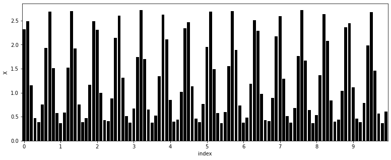

```python
length = 100
x = np.exp(np.sin(np.linspace(1,length,length)))
data = pd.DataFrame(data=x,columns=['X'])
data.reset_index(inplace=True)
plt.figure(figsize=(13,5)) # resizing figure
sns.barplot(y="X", data=data, x="index", color='black'); # Plot from Seaborn
plt.xticks(data['index'][::10]);   # reshape the xtick every 10 observations
```

下面定义并绘制缩放后的变量。

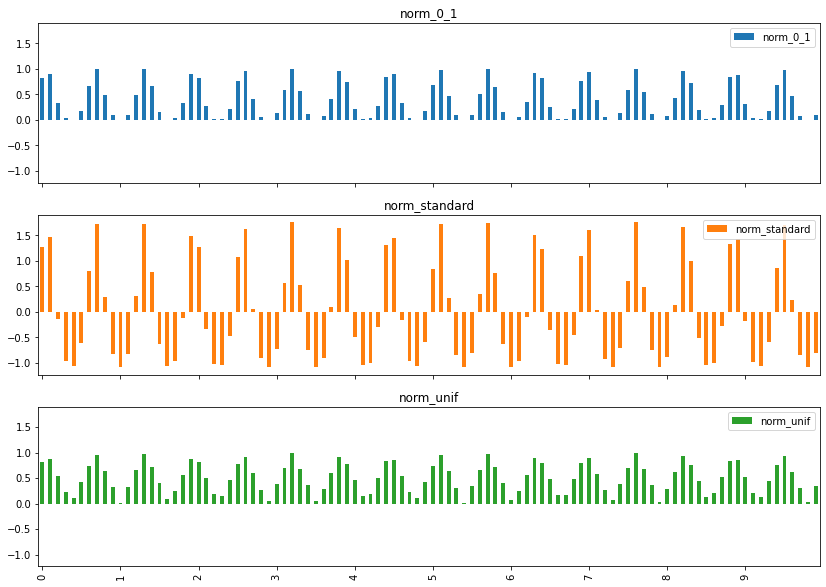

```python
from statsmodels.distributions.empirical_distribution import ECDF # to use the ECDF built in function
def norm_0_1(x):
    return (x-np.min(x))/(np.max(x)-np.min(x))
def norm_unif(x):
    return (ECDF(x)(x))
def norm_standard(x):
    return (x- np.mean(x))/np.std(x)

data_norm=pd.DataFrame.from_dict(dict( # ensembling numpy arrays into a dict and then a pd dataframe
index=np.linspace(1,length,length), # creating the index
norm_0_1=norm_0_1(x), # normalisation [0,1]
norm_standard=norm_standard(x), # standardisation
norm_unif=norm_unif(x))) # Uniformisation
data_norm.iloc[:,1:4].plot.bar( figsize=(14,10), subplots=True, sharey=True, sharex=True); # Plot
plt.xticks(data['index'][::10]);   # reshape the xtick every 10 observations
```

最后，我们查看新创建变量的直方图。

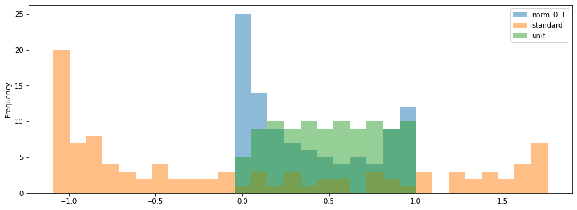

```python
data_norm.iloc[:,1:4].plot.hist(alpha=0.5, bins=30, figsize=(14,5)); # Plot from pandas, alphas=opacity
```

从分布形状看，蓝色与橙色曲线都接近原始分布，变化的只是取值范围：min-max 缩放保证所有数值都落在 $[0,1]$ 区间。原始分布和 min-max 缩放后的分布都在左端形成尖峰。均匀化则按构造消除了这一尖峰，使各数据点在单位区间内均匀分布。

### 4.8.2 缩放的影响：简化示例

为说明选择某一种缩放方法的影响，$^{13}$ 我们构造一个简单数据集，包含 3 家公司和 3 个日期。

```python
import statsmodels.api as sm
from IPython.display import display, Markdown
cap=np.array([10,50,100, # Market capitalization
              15,10,15,
              200,120,80])
returns=np.array([0.06,0.01,-0.06, # Return values
        -0.03,0.00,0.02,
        -0.04,-0.02,0.00])
date=np.array([1,2,3,1,2,3,1,2,3]) # Dates
firm=np.array([1,1,1,2,2,2,3,3,3]) # Firms (3 lines for each)
toy_data=pd.DataFrame.from_dict(dict(firm=firm,date=date,cap=cap,returns=returns, # Aggregation of data
cap_norm=norm_0_1(cap),
cap_u=norm_unif(cap)))
display(Markdown(toy_data.to_markdown())) # Introducing Markdown and printing the table
```

|  | firm | date | cap | returns | cap_norm | cap_u |
| --- | --- | --- | --- | --- | --- | --- |
| 0 | 1 | 1 | 10 | 0.06 | 0 | 0.222222 |
| 1 | 1 | 2 | 50 | 0.01 | 0.210526 | 0.555556 |
| 2 | 1 | 3 | 100 | -0.06 | 0.473684 | 0.777778 |
| 3 | 2 | 1 | 15 | -0.03 | 0.0263158 | 0.444444 |
| 4 | 2 | 2 | 10 | 0 | 0 | 0.222222 |
| 5 | 2 | 3 | 15 | 0.02 | 0.0263158 | 0.444444 |
| 6 | 3 | 1 | 200 | -0.04 | 1 | 1 |
| 7 | 3 | 2 | 120 | -0.02 | 0.578947 | 0.888889 |
| 8 | 3 | 3 | 80 | 0 | 0.368421 | 0.666667 |

表 4.3：简化示例的样本数据。

先简要分析这组合成数据。假设各日期按时间先后排列，且彼此相距很远：每个日期代表某一年或某个十年的起点，但未来收益率仍按月计算。公司 1 发展非常成功，市值在各期之间增长了十倍；公司 2 的市值基本稳定，公司 3 则大幅下降。逐家公司观察未来收益率时，公司 1 和公司 3 的收益率都与规模呈明显负相关，公司 2 则没有清晰规律。

逐日期看，分析相当类似，不过略有细微差别。

- 在日期 1，最小公司收益率最高，另外两家公司收益率为负。
- 在日期 2，最大公司收益率为负，而两家较小公司不是。
- 在日期 3，收益率随规模增大而下降。 尽管这种关系并非始终严格单调，规模与收益率之间仍然存在明显联系；在当前样本中，投资规模最小的公司通常会取得很好的表现。

现在看一下简单回归的输出。

```python
X=toy_data.cap_norm.to_numpy()
X=sm.add_constant(X)
model = sm.OLS(returns, X)
results = model.fit()
print(results.summary())
```

```
                            OLS Regression Results
==============================================================================
Dep. Variable:                      y   R-squared:                       0.379
Model:                            OLS   Adj. R-squared:                  0.290
Method:                 Least Squares   F-statistic:                     4.265
Date:                Tue, 12 Oct 2021   Prob (F-statistic):             0.0778
Time:                        22:09:35   Log-Likelihood:                 19.892
No. Observations:                   9   AIC:                            -35.78
Df Residuals:                       7   BIC:                            -35.39
Df Model:                           1
Covariance Type:            nonrobust
==============================================================================
                 coef    std err          t      P>|t|      [0.025      0.975]
------------------------------------------------------------------------------
const          0.0124      0.014      0.912      0.392      -0.020       0.045
x1            -0.0641      0.031     -2.065      0.078      -0.137       0.009
==============================================================================
Omnibus:                        0.200   Durbin-Watson:                   0.872
Prob(Omnibus):                  0.905   Jarque-Bera (JB):                0.152
Skew:                          -0.187   Prob(JB):                        0.927
Kurtosis:                       2.485   Cond. No.                         3.40
==============================================================================

Notes:
[1] Standard Errors assume that the covariance matrix of the errors is correctly specified.
```

表 4.4：自变量来自 min-max 缩放时的回归输出

```python
X=toy_data.cap_u.to_numpy()
X=sm.add_constant(X)
model = sm.OLS(returns, X)
results = model.fit()
print(results.summary())
```

```
                            OLS Regression Results
==============================================================================
Dep. Variable:                      y   R-squared:                       0.488
Model:                            OLS   Adj. R-squared:                  0.415
Method:                 Least Squares   F-statistic:                     6.672
Date:                Tue, 12 Oct 2021   Prob (F-statistic):             0.0363
Time:                        22:10:01   Log-Likelihood:                 20.764
No. Observations:                   9   AIC:                            -37.53
Df Residuals:                       7   BIC:                            -37.13
Df Model:                           1
Covariance Type:            nonrobust
==============================================================================
                 coef    std err          t      P>|t|      [0.025      0.975]
------------------------------------------------------------------------------
const          0.0457      0.022      2.056      0.079      -0.007       0.098
x1            -0.0902      0.035     -2.583      0.036      -0.173      -0.008
==============================================================================
Omnibus:                        1.603   Durbin-Watson:                   0.918
Prob(Omnibus):                  0.449   Jarque-Bera (JB):                0.895
Skew:                          -0.428   Prob(JB):                        0.639
Kurtosis:                       1.715   Cond. No.                         5.20
==============================================================================

Notes:
[1] Standard Errors assume that the covariance matrix of the errors is correctly specified.
```

表 4.5：自变量来自均匀化时的回归输出

从 p **值**（P>|t| 列）看，第一种方法估计的 cap 系数 p 值高于 5%（表 4.4），第二种则低于 5%（表 4.5）。一个可能的解释是变量的标准差不同：cap_norm 和 cap_u 的标准差分别为 0.34 和 0.27。市值等变量的原始取值范围很大，即使缩放后仍可能具有较高离散度。均匀化能够降低这种离散程度，从而缓解问题。

注意，这是一把**双刃剑**：它虽然有助于避免**假阴性**，但也可能导致**假阳性**。

## 4.9 编程练习

1. 圣路易斯联邦储备银行（https://fred.stlouisfed.org）托管了数千条可作为条件变量的经济指标时间序列。选择其中一条，并应用公式 (4.3) 来扩展预测变量数量。如有需要，可使用上面定义的函数。
2. 基于公式 (4.4) 和 (4.2) 创建一个新的类别型标签。VIX 时间序列也可以从美联储网站获取：https://fred.stlouisfed.org/series/VIXCLS。
3. 绘制 R12M_Usd 变量的直方图。显然，其中存在一些异常值。找出该变量取值最高的股票，并判断该数值是否可能正确。

### 参考文献

Aggarwal, Charu C. 2013. Outlier Analysis. Springer.

Allison, Paul D. 2001. Missing Data. Vol. 136. Sage publications.

Boehmke, Brad, and Brandon Greenwell. 2019. Hands-on Machine Learning with R. Chapman & Hall / CRC.

Chandola, Varun, Arindam Banerjee, and Vipin Kumar. 2009. “Anomaly Detection: A Survey.” ACM Computing Surveys (CSUR) 41 (3): 15.

Che, Zhengping, Sanjay Purushotham, Kyunghyun Cho, David Sontag, and Yan Liu. 2018. “Recurrent Neural Networks for Multivariate Time Series with Missing Values.” Scientific Reports 8 (1): 6085.

Chen, Long, Zhi Da, and Richard Priestley. 2012. “Dividend Smoothing and Predictability.” Management Science 58 (10): 1834–53.

Coqueret, Guillaume, and Tony Guida. 2020. “Training Trees on Tails with Applications to Portfolio Choice.” Annals of Operations Research 288: 181–221.

De Prado, Marcos Lopez. 2018. Advances in Financial Machine Learning. John Wiley & Sons.

Dixon, Matthew F. 2020. “Industrial Forecasting with Exponentially Smoothed Recurrent Neural Networks.” SSRN Working Paper, no. 3572181.

Enders, Craig K. 2001. “A Primer on Maximum Likelihood Algorithms Available for Use with Missing Data.” Structural Equation Modeling 8 (1): 128–41.

Enders, Craig K. 2010. Applied Missing Data Analysis. Guilford Press.

Freyberger, Joachim, Andreas Neuhierl, and Michael Weber. 2020. “Dissecting Characteristics Nonparametrically.” Review of Financial Studies 33 (5): 2326–77.

Fu, XingYu, JinHong Du, YiFeng Guo, MingWen Liu, Tao Dong, and XiuWen Duan. 2018. “A Machine Learning Framework for Stock Selection.” arXiv Preprint, no. 1806.01743.

Galili, Tal, and Isaac Meilijson. 2016. “Splitting Matters: How Monotone Transformation of Predictor Variables May Improve the Predictions of Decision Tree Models.” arXiv Preprint, no. 1611.04561.

Garcı́a-Laencina, Pedro J, José-Luis Sancho-Gómez, Anı́bal R Figueiras-Vidal, and Michel Verleysen. 2009. “K Nearest Neighbours with Mutual Information for Simultaneous Classification and Missing Data Imputation.” Neurocomputing 72 (7-9): 1483–93.

Geman, Stuart, Elie Bienenstock, and René Doursat. 1992. “Neural Networks and the Bias/Variance Dilemma.” Neural Computation 4 (1): 1–58.

Gong, Qiang, Ming Liu, and Qianqiu Liu. 2015. “Momentum Is Really Short-Term Momentum.” Journal of Banking & Finance 50: 169–82.

Gonzalo, Jesús, and Jean-Yves Pitarakis. 2018. “Predictive Regressions.” In Oxford Research Encyclopedia of Economics and Finance.

Goyal, Amit, and Sunil Wahal. 2015. “Is Momentum an Echo?” Journal of Financial and Quantitative Analysis 50 (6): 1237–67.

Gu, Shihao, Bryan T Kelly, and Dacheng Xiu. 2020b. “Empirical Asset Pricing via Machine Learning.” Review of Financial Studies 33 (5): 2223–73.

Guida, Tony, and Guillaume Coqueret. 2018a. “Ensemble Learning Applied to Quant Equity: Gradient Boosting in a Multifactor Framework.” In Big Data and Machine Learning in Quantitative Investment, 129–48. Wiley.

Guida, Tony, and Guillaume Coqueret. 2018b. “Machine Learning in Systematic Equity Allocation: A Model Comparison.” Wilmott 2018 (98): 24–33.

Gupta, Manish, Jing Gao, Charu Aggarwal, and Jiawei Han. 2014. “Outlier Detection for Temporal Data.” IEEE Transactions on Knowledge and Data Engineering 26 (9): 2250–67.

Guyon, Isabelle, and André Elisseeff. 2003. “An Introduction to Variable and Feature Selection.” Journal of Lachine Learning Research 3 (Mar): 1157–82.

Hastie, Trevor, Robert Tibshirani, and Jerome Friedman. 2009. The Elements of Statistical Learning. Springer.

Hodge, Victoria, and Jim Austin. 2004. “A Survey of Outlier Detection Methodologies.” Artificial Intelligence Review 22 (2): 85–126.

Honaker, James, and Gary King. 2010. “What to Do About Missing Values in Time-Series Cross-Section Data.” American Journal of Political Science 54 (2): 561–81.

Jegadeesh, Narasimhan, and Sheridan Titman. 1993. “Returns to Buying Winners and Selling Losers: Implications for Stock Market Efficiency.” Journal of Finance 48 (1): 65–91.

Kelly, Bryan T, Seth Pruitt, and Yinan Su. 2019. “Characteristics Are Covariances: A Unified Model of Risk and Return.” Journal of Financial Economics 134 (3): 501–24.

Kuhn, Max, and Kjell Johnson. 2019. Feature Engineering and Selection: A Practical Approach for Predictive Models. CRC Press.

Leary, Mark T, and Roni Michaely. 2011. “Determinants of Dividend Smoothing: Empirical Evidence.” Review of Financial Studies 24 (10): 3197–3249.

Little, Roderick JA, and Donald B Rubin. 2014. Statistical Analysis with Missing Data. Vol. 333. John Wiley & Sons.

Novy-Marx, Robert. 2012. “Is Momentum Really Momentum?” Journal of Financial Economics 103 (3): 429–53.

Rousseeuw, Peter J, and Annick M Leroy. 2005. Robust Regression and Outlier Detection. Vol. 589. Wiley.

Schafer, Joseph L. 1999. “Multiple Imputation: A Primer.” Statistical Methods in Medical Research 8 (1): 3–15.

Settles, Burr. 2009. “Active Learning Literature Survey.” University of Wisconsin-Madison Department of Computer Sciences.

Settles, Burr. 2012. “Active Learning.” Synthesis Lectures on Artificial Intelligence and Machine Learning 6 (1): 1–114.

Shah, Anoop D, Jonathan W Bartlett, James Carpenter, Owen Nicholas, and Harry Hemingway. 2014. “Comparison of Random Forest and Parametric Imputation Models for Imputing Missing Data Using Mice: A Caliber Study.” American Journal of Epidemiology 179 (6): 764–74.

Stambaugh, Robert F. 1999. “Predictive Regressions.” Journal of Financial Economics 54 (3): 375–421.

Stekhoven, Daniel J, and Peter Bühlmann. 2011. “MissForest—Non-Parametric Missing Value Imputation for Mixed-Type Data.” Bioinformatics 28 (1): 112–18.

Van Buuren, Stef. 2018. Flexible Imputation of Missing Data. Chapman & Hall / CRC.

脚注

10 有些方法确实会将公司属性映射为最终权重，例如 Brandt, Santa-Clara, and Valkanov (2009) 以及 Ammann, Coqueret, and Schade (2016)，但这些超出了本书范围。↩︎

11 当然，对依赖线性模型的推断而言并非如此。记忆性会产生许多问题，并使估计量研究复杂化。关于这一问题的理论和实证结果，可参见 Hjalmarsson (2011) 与 Xu (2020)。↩︎

12 关于特征工程影响的更深入技术讨论，可参见 Galili and Meilijson (2016)。↩︎